# Ego centric network for Academic motivation

2025-03-29

### Data cleaning

```r
egoattributes <- read.csv("SNAP-19-SN_March+13,+2025_09.45.csv")
##Remove those with empty egoties
egoattributes[770:775, 50:51] #detect where is the old/new data boundary
```

```
##         Q18_10_TEXT person21_1
## 770
## 771
## 772
## 773                          6
## 774                         10
## 775 attends college          0
```

```r
alldat<- egoattributes %>%
  filter(row_number() >= 773)
alldat[1:5, 50:51] #confirm the cutoff is correct
```

```
##       Q18_10_TEXT person21_1
## 1                          6
## 2                         10
## 3 attends college          0
## 4                         10
## 5                         10
```

```r
alldat<- subset(alldat, DistributionChannel!="preview") #remove non-data (preview only)
nrow(alldat)
```

```
## [1] 1732
```

```r
##assign ID numbers
alldat$egoID <- 1001:(1000+nrow(alldat))
```

## Initital Sample

```r
originaln<-nrow(alldat) # 1732 (total signed up for the study)
## Cleaning by "Finished" rate
alldat <- subset(alldat, Finished==1)
##Cleaning by participants' incomplete data not detected by "finished"
alldat <- subset(alldat, egoID!=1047)
alldat <- subset(alldat, egoID!=1184)
##Cleaning by participants who did not answer any alters and thus considered incomplete
alldat<- subset(alldat, nchar(Q1_1)!=0)
incompleten<-nrow(alldat) # 1486 (after cleaning all incomplete)

alldat <- subset(alldat, egoID!="1553") #random answers
randomn<-nrow(alldat) #1485

## Cleaning by participants who answered less than 5 minutes
##Other cleaning
alldat<- subset(alldat, Duration..in.seconds.>=300)
shortn<-nrow(alldat) # 1052

#Hmisc::describe(alldat$Q119)
```

### clean inappropriate alter names

Check:

```r
#unique(alldat$Q19_7_TEXT)
```

```r
#same ip, time, names
#alldat <- filter(alldat, !(Q1_1 %in% c("yvonne meaux", "Yvonne meaux")))

#alldat[alldat$egoID==1815, ]
##1762??? i m her grandchild not
##2000???
#1271 god
alldat$Q19_7_TEXT[alldat$Q22_3_TEXT=="He's God"]<-"god"
##1818/1819

#columns 19-28 = alternames
for (i in 19:28){
  alldat[,i]<-tolower(alldat[,i])
  alldat[,i][alldat[,i]=='na' & alldat$Q43 == 3] <- "incorrect"
  alldat[,i][alldat[,i]=='n.a'|alldat[,i]=='n/a'|alldat[,i]=='na'|alldat[,i]=='-'|alldat[,i]=='--'|alldat[,i]==' '] <- "incorrect"
  alldat[,i][alldat[,i]=='myself'] <- "incorrect"
  alldat[,i][grepl('god',alldat[,i])] <- "incorrect"
##Cleaning by participants who answered any incorrect alters
  alldat<-subset(alldat, alldat[,i]!="incorrect")
}
```

### clean inappropriate alter relationships (myself/God)

```r
#identify columns number
alterrelat_var<-c(30,41,53,66, 80, 95,111,128,146,165)

###code all inappropriate relation with 999 so that later when deleting ties, we can use 999 to identify and delete inappropriate ties (rather than deleting the data of the whole participant)

for (i in alterrelat_var){
  alldat[,i]<-tolower(alldat[,i])
  alldat[,i-1][alldat[,i] %in% c('myself','myself ','self','me', 'he is god.','god', 'dog',
                                 "it's me ;)")] <- 999 #"bad person" seem legit and was not deleted.
  alldat[,i-1][grepl('self|god|myself|me', alldat[,i])]<-999
  alldat[,i][alldat[,i] %in% c('myself','myself ','self','me', 'he is god.','god', 'dog', #recode relationship as NA
                                 "it's me ;)")] <- "incorrect"
##Cleaning by participants who answered any inappropriate alters
  alldat<-subset(alldat, alldat[,i-1]!=999)
  alldat<-subset(alldat, alldat[,i]!="incorrect")

}
namen<-nrow(alldat) #after cleaning god/myself 968

###alldat[,i][startsWith(alldat[,i], "it")]<-''
```

### Code alter relationships

1 = Parent 2 = Child (recode to combine with 1) 3 = Sibling 4 = Relative 5 = Spouse/romantic partner/sig other 6 = Friend/peer 7 = Other (unidentified) 8 = teacher figures 9 = mental health professions (counselor, therapist, psychiatrist) 10 = other adults (caretaker role, nanny, parent figure) 11 = work 12 = church/religious

```r
for (i in alterrelat_var){
  alldat[,i]<-tolower(alldat[,i])

  alldat[,i-1][alldat[,i-1]==2]<-1 #all parent-child categories, including step

  alldat[,i-1][grepl('pastor|church|minister',alldat[,i])] <- 12  #church
  alldat[,i][grepl('pastor|church|minister',alldat[,i])] <- "church"  #church

  alldat[,i-1][grepl("friends dad|family friend|boyfriends mom|mothers friend|bestfriends mom|friend's mom|doctor|chiropractor|owner of my house|patient|neighbor|sponsor|book|parentfig|my nanny|nfl player", alldat[,i])] <- 10
  alldat[,i][grepl("friends dad|family friend|boyfriends mom|mothers friend|bestfriends mom|friend's mom|doctor|chiropractor|owner of my house|patient|neighbor|sponsor|book|parentfig|my nanny|nfl player", alldat[,i])]  <- "othr_adults"

  alldat[,i-1][grepl('grand|gm|grandparent|grandchild', alldat[,i])] <-4
  alldat[,i][grepl('grand|gm|grandparent|grandchild', alldat[,i])] <-"grandparent"

  alldat[,i-1][alldat[,i] %in% c('cousin','uncle','uncle ','bnl'
                                 ,'aunt','brothers wife','brother in law','mother n law',
                                 'significant others parent','family','sister in law','brother-in-law',
                                 'sister  in law','sister-in-law')] <- 4 #relatives
  alldat[,i][alldat[,i] %in% c('cousin','uncle', 'uncle ', 'bnl'
                                 ,'aunt','brothers wife','brother in law','mother n law',
                                 'significant others parent','family','sister in law','brother-in-law',
                               'sister  in law','sister-in-law')] <- "relatives" #relatives

  alldat[,i-1][grepl('step|parent|mom|dad|mother|father|pa pa|moms bf|dads gf|legal guardian|pa pa', alldat[,i])] <- 1
  alldat[,i][grepl('step|parent|mom|dad|mother|father|pa pa|moms bf|dads gf|legal guardian|pa pa', alldat[,i])] <- "parentfig"

  alldat[,i-1][grepl('boss|work|employ',alldat[,i])] <- 11  #work exboss
  alldat[,i][grepl('boss|work|employ',alldat[,i])] <- "work"  #work

  alldat[,i-1][grepl('ex|former partner',alldat[,i])] <- 5 ##past/current sign other
  alldat[,i][grepl('ex|former partner',alldat[,i])] <- "sigother" #past/current sign other

  alldat[,i-1][grepl('classmate|organization leader|acquintance|friend|room|peer',alldat[,i])] <- 6 ##peer
  alldat[,i][grepl('classmate|organization leader|acquintance|friend|room|peer',alldat[,i])] <- "peer" #peer

  alldat[,i-1][grepl('couns|admin|mentor|student|band|college|teach|advis|tutor|councelor|chemistry aid|
                      academic|princ|school|train|coach|faculty|instructor|profess|guidance|educator',alldat[,i])] <- 8 #teacherfigures
  alldat[,i][grepl('couns|admin|mentor|student|band|college|teach|advis|tutor|councelor|chemistry aid|
                    academic|princ|school|train|coach|faculty|instructor|profess|guidance|educator',alldat[,i])] <- "academic" #MHfigures
  alldat[,i-1][grepl('therapist|psychiat',alldat[,i])] <- 9
  alldat[,i][grepl('therapist|psychiat',alldat[,i])] <- "mentalhealth"

  alldat[,i-1][alldat[,i] %in% c('dont know him','nothing','na','bad person ')] <- 7 #unidentified
  alldat[,i][alldat[,i] %in% c('dont know him','nothing','na','bad person ')] <- NA #unidentified

  #alldat[,i][alldat[,i]==""]<-NA
}
```

Check again

```r
# Combine all the data into one vector
combined_data <- c(alldat$Q2_7_TEXT, alldat$Q11_7_TEXT, alldat$Q19_7_TEXT, alldat$Q27_7_TEXT,
                   alldat$Q35_7_TEXT, alldat$Q43_7_TEXT, alldat$Q51_7_TEXT, alldat$Q59_7_TEXT,
                   alldat$Q67_7_TEXT, alldat$Q75_7_TEXT)

# Find unique values
unique_values <- unique(combined_data)

# Calculate the frequency of each unique value
frequency_table <- table(combined_data)

# Print the frequency table
print(frequency_table)
```

```
## combined_data
##                  academic       church mentalhealth  othr_adults    parentfig
##         8934          553            7           17           28           89
##         peer    relatives     sigother         work
##           10           19            6           15
```

### Ego Attribute Dataset

```r
egoattributes <-  dplyr::select(alldat, egoID, Q94_1:Q120, -Q2_3_TEXT, -Q3_9_TEXT, - Q3_7_TEXT)
# Convert character columns with numeric values to numeric
egoattributes <- egoattributes %>%
  mutate_if(is.character, as.numeric)
str(egoattributes)
```

```
## 'data.frame':    968 obs. of  38 variables:
##  $ egoID : int  1001 1002 1005 1006 1007 1008 1009 1012 1014 1015 ...
##  $ Q94_1 : num  5 2 4 4 3 4 3 4 5 5 ...
##  $ Q94_2 : num  4 5 4 4 4 3 5 2 3 4 ...
##  $ Q94_3 : num  5 5 4 4 5 4 5 2 5 5 ...
##  $ Q94_4 : num  1 1 4 4 3 4 2 2 3 1 ...
##  $ Q94_5 : num  1 2 4 4 1 1 1 2 2 1 ...
##  $ Q94_6 : num  3 2 4 4 2 3 3 2 5 3 ...
##  $ Q96_1 : num  5 4 4 4 5 2 3 3 5 5 ...
##  $ Q96_2 : num  5 4 4 4 5 3 4 2 5 5 ...
##  $ Q96_3 : num  3 4 4 4 5 3 4 2 3 4 ...
##  $ Q96_4 : num  5 5 4 4 5 4 4 2 5 5 ...
##  $ Q96_5 : num  3 1 4 4 3 3 2 2 1 1 ...
##  $ Q96_6 : num  1 3 4 4 1 1 1 2 1 1 ...
##  $ Q98_1 : num  3 2 4 4 5 2 3 2 5 5 ...
```

[output cut: 24 more lines]

#### Recoding and finding reliability for ext_/external regulation

```r
ext_reg <- select(egoattributes, Q94_1, Q96_2, Q98_3, Q100_4)
egoattributes$ext_reg<-rowMeans(ext_reg)
psych::alpha(ext_reg)$total$raw_alpha
```

```
## [1] 0.7997595
```

```r
#describe(egoattributes$ext_reg)
```

#### Recoding and finding reliability for Intrinsic/to know

```r
int_toknow <- select(egoattributes, Q94_2, Q96_3, Q98_4, Q100_5)
egoattributes$int_toknow<-rowMeans(int_toknow)
#psych::alpha(int_toknow)
#describe(egoattributes$int_toknow)
```

#### Recoding and finding reliability for ext_/identified

```r
ext_iden <- select(egoattributes, Q94_3, Q96_4, Q98_5, Q100_6)
egoattributes$ext_iden<-rowMeans(ext_iden)
#psych::alpha(ext_iden)
#describe(egoattributes$ext_iden)
```

#### Recoding and finding reliability for Intrinsic/stimulation

```r
int_stim <- select(egoattributes, Q94_4, Q96_5, Q98_6, Q102_1)
egoattributes$int_stim<-rowMeans(int_stim)
#psych::alpha(int_stim)
#describe(egoattributes$int_stim)
```

#### Recoding and finding reliability for Amotivation

```r
amotiv <- select(egoattributes, Q94_5, Q96_6, Q100_1, Q102_2)
egoattributes$amotiv<-rowMeans(amotiv)
#psych::alpha(amotiv)
#describe(egoattributes$amotiv)
```

#### Recoding and finding reliability for Intrinsic/Accomplishment

```r
int_accomp <- select(egoattributes, Q94_6, Q98_1, Q100_2, Q102_3)
egoattributes$int_accomp<-rowMeans(int_accomp)
#psych::alpha(int_accomp)
#describe(egoattributes$int_accomp)
```

#### Recoding and finding reliability for ext_/introjected

```r
ext_intro <- select(egoattributes, Q96_1, Q98_2, Q100_3, Q102_4)
egoattributes$ext_intro<-rowMeans(ext_intro)
#psych::alpha(ext_intro)
#describe(egoattributes$ext_intro)
```

```r
egoattributes <- rename(egoattributes, ego.gender=Q2.1, ego.race=Q3, ego.workhours=Q4
                        , ego.studentorg=Q6.1, ego.belong=Q107
                        , ego.acadval=Q91_1, ego.careerval=Q92_1
                        , ego.age=Q119, ego.year=Q120
                        )

##Recode attritbues where necessary

egoattributes$ego.genderbi[egoattributes$ego.gender==1]<-0 #"female"
egoattributes$ego.genderbi[egoattributes$ego.gender==2]<-1 #"male"
egoattributes$ego.genderbi[egoattributes$ego.gender==3]<-NA #"non-binary"
egoattributes$ego.racetri[egoattributes$ego.race==1]<-1 #White
egoattributes$ego.racetri[egoattributes$ego.race==2]<-2 #Black
egoattributes$ego.racetri[egoattributes$ego.race>=3]<-3 #Other
```

## Alter Attributes with ego-alter ties

```r
##alter data by sequence
alter01<-dplyr::select(alldat, egoID, Q1_1, Q2:Q10_10_TEXT,
                           person21_1,
                           Q110_4,  Q110_5,
                           Q111_4,  Q111_5,  Q111_6,
                           Q112_4,  Q112_5,  Q112_6,  Q112_7,
                           Q113_4,  Q113_5,  Q113_6,  Q113_7,  Q113_8,
                           Q114_4,  Q114_5,  Q114_6,  Q114_7,  Q114_8,  Q114_9,
                           Q115_4,  Q115_5,  Q115_6,  Q115_7,  Q115_8,  Q115_9,  Q115_10,
                           Q116_4,  Q116_5,  Q116_6,  Q116_7,  Q116_8,  Q116_9,  Q116_10,  Q116_11,
                           Q117_4,  Q117_5,  Q117_6,  Q117_7,  Q117_8,  Q117_9,  Q117_10,  Q117_11,  Q117_12)
alter02<-dplyr::select(alldat, egoID, Q1_2, Q11:Q18_10_TEXT,
                           person21_1,
                           Q110_4,  Q110_5,
                           Q111_4,  Q111_5,  Q111_6,
                           Q112_4,  Q112_5,  Q112_6,  Q112_7,
                           Q113_4,  Q113_5,  Q113_6,  Q113_7,  Q113_8,
                           Q114_4,  Q114_5,  Q114_6,  Q114_7,  Q114_8,  Q114_9,
                           Q115_4,  Q115_5,  Q115_6,  Q115_7,  Q115_8,  Q115_9,  Q115_10,
                           Q116_4,  Q116_5,  Q116_6,  Q116_7,  Q116_8,  Q116_9,  Q116_10,  Q116_11,
                           Q117_4,  Q117_5,  Q117_6,  Q117_7,  Q117_8,  Q117_9,  Q117_10,  Q117_11,  Q117_12)
alter03<-dplyr::select(alldat, egoID, Q1_3, Q19:Q26_10_TEXT,
                           person21_1,
                           Q110_4,  Q110_5,
                           Q111_4,  Q111_5,  Q111_6,
                           Q112_4,  Q112_5,  Q112_6,  Q112_7,
                           Q113_4,  Q113_5,  Q113_6,  Q113_7,  Q113_8,
                           Q114_4,  Q114_5,  Q114_6,  Q114_7,  Q114_8,  Q114_9,
                           Q115_4,  Q115_5,  Q115_6,  Q115_7,  Q115_8,  Q115_9,  Q115_10,
                           Q116_4,  Q116_5,  Q116_6,  Q116_7,  Q116_8,  Q116_9,  Q116_10,  Q116_11,
                           Q117_4,  Q117_5,  Q117_6,  Q117_7,  Q117_8,  Q117_9,  Q117_10,  Q117_11,  Q117_12)
alter04<-dplyr::select(alldat, egoID, Q1_4, Q27:Q34_10_TEXT,
                           person21_1,
                           Q110_4,  Q110_5,
                           Q111_4,  Q111_5,  Q111_6,
                           Q112_4,  Q112_5,  Q112_6,  Q112_7,
                           Q113_4,  Q113_5,  Q113_6,  Q113_7,  Q113_8,
                           Q114_4,  Q114_5,  Q114_6,  Q114_7,  Q114_8,  Q114_9,
                           Q115_4,  Q115_5,  Q115_6,  Q115_7,  Q115_8,  Q115_9,  Q115_10,
                           Q116_4,  Q116_5,  Q116_6,  Q116_7,  Q116_8,  Q116_9,  Q116_10,  Q116_11,
                           Q117_4,  Q117_5,  Q117_6,  Q117_7,  Q117_8,  Q117_9,  Q117_10,  Q117_11,  Q117_12)
alter05<-dplyr::select(alldat, egoID, Q1_5, Q35:Q42_10_TEXT,
                           person21_1,
                           Q110_4,  Q110_5,
                           Q111_4,  Q111_5,  Q111_6,
                           Q112_4,  Q112_5,  Q112_6,  Q112_7,
                           Q113_4,  Q113_5,  Q113_6,  Q113_7,  Q113_8,
                           Q114_4,  Q114_5,  Q114_6,  Q114_7,  Q114_8,  Q114_9,
                           Q115_4,  Q115_5,  Q115_6,  Q115_7,  Q115_8,  Q115_9,  Q115_10,
                           Q116_4,  Q116_5,  Q116_6,  Q116_7,  Q116_8,  Q116_9,  Q116_10,  Q116_11,
                           Q117_4,  Q117_5,  Q117_6,  Q117_7,  Q117_8,  Q117_9,  Q117_10,  Q117_11,  Q117_12)
alter06<-dplyr::select(alldat, egoID, Q1_6, Q43:Q50_10_TEXT,
                           person21_1,
                           Q110_4,  Q110_5,
                           Q111_4,  Q111_5,  Q111_6,
                           Q112_4,  Q112_5,  Q112_6,  Q112_7,
                           Q113_4,  Q113_5,  Q113_6,  Q113_7,  Q113_8,
                           Q114_4,  Q114_5,  Q114_6,  Q114_7,  Q114_8,  Q114_9,
                           Q115_4,  Q115_5,  Q115_6,  Q115_7,  Q115_8,  Q115_9,  Q115_10,
                           Q116_4,  Q116_5,  Q116_6,  Q116_7,  Q116_8,  Q116_9,  Q116_10,  Q116_11,
                           Q117_4,  Q117_5,  Q117_6,  Q117_7,  Q117_8,  Q117_9,  Q117_10,  Q117_11,  Q117_12)
alter07<-dplyr::select(alldat, egoID, Q1_7, Q51:Q58_10_TEXT,
                           person21_1,
                           Q110_4,  Q110_5,
                           Q111_4,  Q111_5,  Q111_6,
                           Q112_4,  Q112_5,  Q112_6,  Q112_7,
                           Q113_4,  Q113_5,  Q113_6,  Q113_7,  Q113_8,
                           Q114_4,  Q114_5,  Q114_6,  Q114_7,  Q114_8,  Q114_9,
                           Q115_4,  Q115_5,  Q115_6,  Q115_7,  Q115_8,  Q115_9,  Q115_10,
                           Q116_4,  Q116_5,  Q116_6,  Q116_7,  Q116_8,  Q116_9,  Q116_10,  Q116_11,
                           Q117_4,  Q117_5,  Q117_6,  Q117_7,  Q117_8,  Q117_9,  Q117_10,  Q117_11,  Q117_12)
alter08<-dplyr::select(alldat, egoID, Q1_8, Q59:Q66_10_TEXT,
                           person21_1,
                           Q110_4,  Q110_5,
                           Q111_4,  Q111_5,  Q111_6,
                           Q112_4,  Q112_5,  Q112_6,  Q112_7,
                           Q113_4,  Q113_5,  Q113_6,  Q113_7,  Q113_8,
                           Q114_4,  Q114_5,  Q114_6,  Q114_7,  Q114_8,  Q114_9,
                           Q115_4,  Q115_5,  Q115_6,  Q115_7,  Q115_8,  Q115_9,  Q115_10,
                           Q116_4,  Q116_5,  Q116_6,  Q116_7,  Q116_8,  Q116_9,  Q116_10,  Q116_11,
                           Q117_4,  Q117_5,  Q117_6,  Q117_7,  Q117_8,  Q117_9,  Q117_10,  Q117_11,  Q117_12)
alter09<-dplyr::select(alldat, egoID, Q1_9, Q67:Q74_10_TEXT,
                           person21_1,
                           Q110_4,  Q110_5,
                           Q111_4,  Q111_5,  Q111_6,
                           Q112_4,  Q112_5,  Q112_6,  Q112_7,
                           Q113_4,  Q113_5,  Q113_6,  Q113_7,  Q113_8,
                           Q114_4,  Q114_5,  Q114_6,  Q114_7,  Q114_8,  Q114_9,
                           Q115_4,  Q115_5,  Q115_6,  Q115_7,  Q115_8,  Q115_9,  Q115_10,
                           Q116_4,  Q116_5,  Q116_6,  Q116_7,  Q116_8,  Q116_9,  Q116_10,  Q116_11,
                           Q117_4,  Q117_5,  Q117_6,  Q117_7,  Q117_8,  Q117_9,  Q117_10,  Q117_11,  Q117_12)

alter10<-dplyr::select(alldat, egoID, Q1_10, Q75:Q82_10_TEXT,
                           person21_1,
                           Q110_4,  Q110_5,
                           Q111_4,  Q111_5,  Q111_6,
                           Q112_4,  Q112_5,  Q112_6,  Q112_7,
                           Q113_4,  Q113_5,  Q113_6,  Q113_7,  Q113_8,
                           Q114_4,  Q114_5,  Q114_6,  Q114_7,  Q114_8,  Q114_9,
                           Q115_4,  Q115_5,  Q115_6,  Q115_7,  Q115_8,  Q115_9,  Q115_10,
                           Q116_4,  Q116_5,  Q116_6,  Q116_7,  Q116_8,  Q116_9,  Q116_10,  Q116_11,
                           Q117_4,  Q117_5,  Q117_6,  Q117_7,  Q117_8,  Q117_9,  Q117_10,  Q117_11,  Q117_12)

ChangeNames <- function(x) {
    names(x) <- c("egoID", "alter.initial", "egoalt_relation", "egoalt_relate_othr"
                     , "egoalter_tie", "egoalter_commfreq", "alter.gender"
                     , "alt.gender_othr"
                     , "alter.age", "alter.acad.val", "alter.career.val","alter.edu"
                     , "alter.edu.othr"
                  , "e0102"
                  , "e0103", "e0203"
                  , "e0104", "e0204", "e0304"
                  , "e0105", "e0205", "e0305", "e0405"
                  , "e0106", "e0206", "e0306", "e0406", "e0506"
                  , "e0107", "e0207", "e0307", "e0407", "e0507", "e0607"
                  , "e0108", "e0208", "e0308", "e0408", "e0508", "e0608", "e0708"
                  , "e0109", "e0209", "e0309", "e0409", "e0509", "e0609", "e0709", "e0809"
                  , "e0110", "e0210", "e0310", "e0410", "e0510", "e0610", "e0710", "e0810", "e0910")
    return(x)
}

ego.alt <- function(x, alterseq) {
  x<-ChangeNames(x)
  x$alterID <- alterseq
  x$alterID<-paste(x$egoID, x$alterID, sep="")
  #x<-subset(x, alter.initial!="")
  return(x)
}

alter01 <- ego.alt(alter01, "01")
alter02 <- ego.alt(alter02, "02")
alter03 <- ego.alt(alter03, "03")
alter04 <- ego.alt(alter04, "04")
alter05 <- ego.alt(alter05, "05")
alter06 <- ego.alt(alter06, "06")
alter07 <- ego.alt(alter07, "07")
alter08 <- ego.alt(alter08, "08")
alter09 <- ego.alt(alter09, "09")
alter10 <- ego.alt(alter10, "10")

alterlist <- mget(ls(pattern= "^alter.\\d$"))
alterattr <- alterlist %>%
  reduce(full_join)
```

[output not shown]

[output cut: 8 more lines]

[output not shown]

## alter characteristics at alter level

```r
#alter_cleaned<-subset(alterattr, nchar(alter.initial)!=0)
alterattr$egoalter_tie<-as.numeric(alterattr$egoalter_tie)
alterattr$alter.age<-as.numeric(alterattr$alter.age)
alterattr$egoalter_commfreq<-as.numeric(alterattr$egoalter_commfreq)
alterattr$alter.career.val<-as.numeric(alterattr$alter.career.val)
alterattr$alter.edu<-as.numeric(alterattr$alter.edu)
alterattr$alter.acad.val<-as.numeric(alterattr$alter.acad.val)


Hmisc::describe(alterattr$alter.gender)
```

```
## alterattr$alter.gender
##        n  missing distinct
##     5629     4051        3
##
## Value          1     2     3
## Frequency   3353  2251    25
## Proportion 0.596 0.400 0.004
```

```r
alterattr$alter.genderbi[alterattr$alter.gender==1]<-0 #female
alterattr$alter.genderbi[alterattr$alter.gender==2]<-1 #male
alterattr$alter.genderbi[alterattr$alter.gender==3]<-NA #non-binary

#summary(as.factor(alterattr$alter.edu))
```

## alter characteristics at ego level (summarise)

```r
ego_avgaltattr <-
  alterattr %>%
  group_by(egoID) %>%
  summarise(mean.clo=mean(egoalter_tie, na.rm=T),
            mean.comm=mean(egoalter_commfreq, na.rm=TRUE),
            mean.careerval=mean(alter.career.val, na.rm=T), mean.acadval= mean(alter.acad.val, na.rm=TRUE),
            mean.edu = mean(alter.edu, na.rm=T), alt.edudiverse = n_distinct(alter.edu, na.rm=T),
            alt.type=n_distinct(egoalt_relation, na.rm=TRUE), alt.age=mean(alter.age, na.rm=T), alt.agesd=sd(alter.age,na.rm=T),
            alt.female= sum(alter.gender==2), alt.male= sum(alter.gender==1),
            alt.genratio = alt.female/alt.male)

egoattributes<-merge(egoattributes, ego_avgaltattr, by="egoID")

#update files
#write.csv(alterattr, "alter_attribute.csv")
#write.csv(egoattributes, "ego_attribute.csv")
```

## alter-alter relationships data

```r
ChangeNames2 <- function(x) {
    names(x) <- c("egoID", "from.alter", "alt.alt.tie","egoalt_relation", "egoalt_relate_othr", "alter.initial", "to.alter")
    return(x)
}


egoalter <-  dplyr::select(alterattr, egoID, alterID, alter.initial, egoalt_relation, egoalt_relate_othr
                          # Q1_1,  Q1_2,  Q1_3,  Q1_4,  Q1_5,  Q1_6,  Q1_7,  Q1_8,
                          # Q1_9,  Q1_10  #initials
                  , e0102
                  , e0103, e0203
                  , e0104, e0204, e0304
                  , e0105, e0205, e0305, e0405
                  , e0106, e0206, e0306, e0406, e0506
                  , e0107, e0207, e0307, e0407, e0507, e0607
                  , e0108, e0208, e0308, e0408, e0508, e0608, e0708
                  , e0109, e0209, e0309, e0409, e0509, e0609, e0709, e0809
                  , e0110, e0210, e0310, e0410, e0510, e0610, e0710, e0810, e0910)



y<-data.frame()
for (i in 1:10){
  for (j in (i+1):10){
    if (i<9 && j < 10){
      a=(paste("0",i,sep=""))
      b=(paste("0",j,sep=""))
      tmp<-subset(egoalter, endsWith(alterID, paste0("0",i)))
      tmp<-dplyr::select(tmp, egoID, alterID, ends_with(paste0(a,b)),egoalt_relation,egoalt_relate_othr,alter.initial)
      tmp$to.alter <- paste0(tmp$egoID, b)
      tmp <- ChangeNames2(tmp)
      y<-rbind(y, tmp)
    }
    if (i<9 && j == 10){
      a=(paste("0",i,sep=""))
      b=(paste(j,sep=""))
      tmp<-subset(egoalter, endsWith(alterID, paste0("0",i)))
      tmp<-dplyr::select(tmp, egoID, alterID, ends_with(paste0(a,b)),egoalt_relation,egoalt_relate_othr,alter.initial)
      tmp$to.alter <- paste0(tmp$egoID, b)
      tmp <- ChangeNames2(tmp)
      y<-rbind(y, tmp)
    }
    if (i==9 ){
      a=(paste("0",i,sep=""))
      b=(paste(j,sep=""))
      tmp<-subset(egoalter, endsWith(alterID, paste0("0",i)))
      tmp<-dplyr::select(tmp, egoID, alterID, ends_with(paste0(a,b)),egoalt_relation,egoalt_relate_othr,alter.initial )
      tmp$to.alter <- paste0(tmp$egoID, b)
      tmp <- ChangeNames2(tmp)
      y<-rbind(y, tmp)
    }
  }}

alter_ties = y
#write.csv(y, "alter_ties.csv")
```

## Clean alter ties that have no relationships

```r
#check responses
#unique(alter_tiestmp$egoalt_relate_othr)
#table(alter_tiestmp$egoalt_relate_othr)

#unique(alter_tiestmp$egoalt_relation)

#https://bookdown.org/rdpeng/rprogdatascience/regular-expressions.html

#regrex in r
alter_tiestmp2 <- subset(alter_ties, nchar(alter.initial)!=0)

#alterattrtmp <- alterattr[((alterattr$alterID %in% alter_ties$from.alter)|(alterattr$alterID %in% alter_ties$to.alter)), ]

alter_tiestmp2$alt.alt.tie<-as.numeric(alter_tiestmp2$alt.alt.tie)
alter_tiestmp3<-subset(alter_tiestmp2, alt.alt.tie!="")
alter_tiestmp3<- dplyr::select(alter_tiestmp3, egoID, from.alter, to.alter, alt.alt.tie)
alter_tiestmp3<- rename(alter_tiestmp3, weight_origin=alt.alt.tie)
#alter_tiestmp3$weight<-alter_tiestmp3$weight_origin+10
alter_tiestmp3$weight<-alter_tiestmp3$weight_origin
alter_tiestmp3$weight[alter_tiestmp3$weight_origin<=0]<-NA #negative or no relationship
alter_tiestmp3<-subset(alter_tiestmp3, is.na(alter_tiestmp3$weight)!=T)
#alter_tiestmp3$weight<-alter_tiestmp3$weight
describe(alter_tiestmp3$weight)
```

```
## alter_tiestmp3$weight
##        n  missing distinct     Info     Mean  pMedian      Gmd      .05
##    12031        0       10    0.912    7.539        8    3.031        2
##      .10      .25      .50      .75      .90      .95
##        3        6        9       10       10       10
##
## Value          1     2     3     4     5     6     7     8     9    10
## Frequency    440   550   526   738   712   944   935  1110   778  5298
## Proportion 0.037 0.046 0.044 0.061 0.059 0.078 0.078 0.092 0.065 0.440
##
## For the frequency table, variable is rounded to the nearest 0
```

```r
#write.csv(alter_tiestmp2,"alter_tiestmp2_allegos.csv")
#write.csv(alter_tiestmp3,"alter_tiestmp3.csv") #only with at least one alt-alt tie.
```

### egoIDs who completed the survey but did not report any alter-alter ties.

```r
# Get unique egoIDs from both datasets
egoIDs_in_tiestmp2 <- unique(alter_tiestmp2$egoID)
egoIDs_in_tiestmp3 <- unique(alter_tiestmp3$egoID)

# Identify egoIDs present in alter_tiestmp2 but not in alter_tiestmp3
missing_egoIDs <- setdiff(egoIDs_in_tiestmp2, egoIDs_in_tiestmp3)

# Print the missing egoIDs
print(missing_egoIDs)
```

```
##  [1] 1006 1015 1053 1061 1078 1091 1101 1112 1133 1134 1166 1198 1204 1259 1263
## [16] 1281 1327 1345 1354 1360 1383 1422 1424 1435 1438 1443 1456 1463 1492 1501
## [31] 1538 1554 1564 1589 1613 1619 1649 1654 1669 1674 1687 1688 1704 1720 1726
## [46] 1729 1747 1770 1831 1838 1871 1891 1938 2003 2010 2038 2052 2081 2104 2105
## [61] 2190 2277 2294 2310 2341 2403 2411 2413 2453 2454 2484 2500 2515 2524 2542
## [76] 2553 2635 2670 2682 2687 2713
```

```r
finaln<-length(missing_egoIDs)
```

## Clean missing in all three sets

### screen excluded egos and alters

#and report final sample size after cleaning

```r
listtemp1<-unique(alter_tiestmp3$egoID) #number of screened participants
alters_screened<-c(alter_tiestmp3$from.alter, alter_tiestmp3$to.alter)
listtemp2<-unique(alters_screened) #number of alters
#number of alter-alter tie = alter_tiestmp3
#egoattributes<-read.csv("ego_attribute.csv")
egoattributes_tmp <- subset(egoattributes, (egoID %in% listtemp1))
#alterattr<-read.csv("alter_attribute.csv")
#alterattr$egoalter_tie_deci<-alterattr$egoalter_tie
#alterattr$egoalter_tie_deci[alterattr$egoalter_tie_deci<=0]<- NA
alterattr_tmp<-alterattr[complete.cases(alterattr),]
alterattr_tmp<-subset(alterattr_tmp, egoID %in% listtemp1)
alterattr_tmp<-subset(alterattr, alterID %in% listtemp2)
#alterattr_tmp$egoalter_tie_deci<-(alterattr_tmp$egoalter_tie_deci)/10
#$alter_tiestmp3<-subset(alter_tiestmp3, alterID %in% listtemp3)

describe(alterattr_tmp$egoalter_tie)
```

```
## alterattr_tmp$egoalter_tie
##        n  missing distinct     Info     Mean  pMedian      Gmd      .05
##     5163       20       20    0.734    8.772      9.5    1.917        4
##      .10      .25      .50      .75      .90      .95
##        6        8       10       10       10       10
##
## Value        -10    -8    -7    -6    -5    -4    -3    -2    -1     0     1
## Frequency      4     3     2     3     7    11     7    17     8    20    17
## Proportion 0.001 0.001 0.000 0.001 0.001 0.002 0.001 0.003 0.002 0.004 0.003
##
## Value          2     3     4     5     6     7     8     9    10
## Frequency     39    37   112   115   264   290   492   403  3312
## Proportion 0.008 0.007 0.022 0.022 0.051 0.056 0.095 0.078 0.641
##
## For the frequency table, variable is rounded to the nearest 0
```

```r
summary(as.factor(alterattr_tmp$egoalter_tie))
```

```
##  -10   -8   -7   -6   -5   -4   -3   -2   -1    0    1    2    3    4    5    6
##    4    3    2    3    7   11    7   17    8   20   17   39   37  112  115  264
##    7    8    9   10 NA's
##  290  492  403 3312   20
```

### descriptive statistics

```r
describe(egoattributes_tmp$ego.gender)
```

```
## egoattributes_tmp$ego.gender
##        n  missing distinct     Info     Mean  pMedian      Gmd
##      886        1        3    0.594    1.292        1   0.4397
##
## Value          1     2     3
## Frequency    648   217    21
## Proportion 0.731 0.245 0.024
##
## For the frequency table, variable is rounded to the nearest 0
```

```r
describe(egoattributes_tmp$ego.race)
```

```
## egoattributes_tmp$ego.race
##        n  missing distinct     Info     Mean  pMedian      Gmd
##      879        8        9    0.683    1.647      1.5    1.044
##
## Value          1     2     3     4     5     6     7     8     9
## Frequency    588   230     8     1    19     1     3    11    18
## Proportion 0.669 0.262 0.009 0.001 0.022 0.001 0.003 0.013 0.020
##
## For the frequency table, variable is rounded to the nearest 0
```

```r
egoattributes_tmp$ego.ager<-egoattributes_tmp$ego.age + 14
describe(egoattributes_tmp$ego.ager)
```

```
## egoattributes_tmp$ego.ager
##        n  missing distinct     Info     Mean  pMedian      Gmd      .05
##      551      336       12    0.802    18.79     18.5    1.145       18
##      .10      .25      .50      .75      .90      .95
##       18       18       18       19       20       21
##
## Value         17    18    19    20    21    22    23    25    26    28    31
## Frequency      1   309   152    50    18     9     3     5     1     1     1
## Proportion 0.002 0.561 0.276 0.091 0.033 0.016 0.005 0.009 0.002 0.002 0.002
##
## Value         33
## Frequency      1
## Proportion 0.002
##
## For the frequency table, variable is rounded to the nearest 0
```

```r
sd(egoattributes_tmp$ego.ager, na.rm=T)
```

```
## [1] 1.471186
```

```r
describe(egoattributes_tmp$ego.year)
```

```
## egoattributes_tmp$ego.year
##        n  missing distinct     Info     Mean  pMedian      Gmd
##      553      334        4    0.643     1.43      1.5   0.6613
##
## Value          1     2     3     4
## Frequency    390   100    51    12
## Proportion 0.705 0.181 0.092 0.022
##
## For the frequency table, variable is rounded to the nearest 0
```

### Egor object generation

```r
egor.obj<-egor::threefiles_to_egor(egos= egoattributes_tmp,
                                   alters.df = alterattr_tmp,
                                   edges = alter_tiestmp3,
                                   ID.vars=list(ego="egoID",
                                                alter="alterID",
                                                source="from.alter",
                                                target="to.alter")
                                   )

summary(egor.obj)
```

```
## 887 Egos/ Ego Networks
## 5183 Alters
## Min. Netsize 2
## Average Netsize 5.84329199549042
## Max. Netsize 10
## Average Density 0.801636513305059
## Alter survey design:
##   Maximum nominations: Inf
```

## Plot graphs for egos and find their network indices

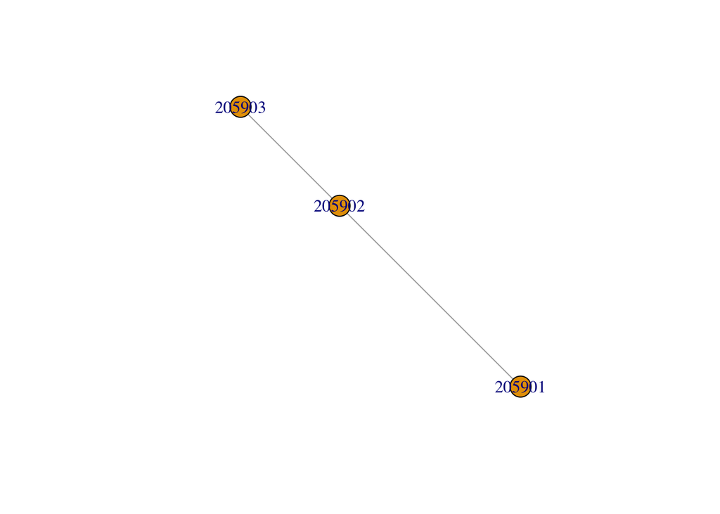

```r
#https://r-graph-gallery.com/248-igraph-plotting-parameters.html

gr.list <- egor::as_igraph(egor.obj) #without ego
gr.list.ego <- egor::as_igraph(egor.obj, include.ego = TRUE) #with ego
#egor::as.egor(gr.list)

gr<-gr.list[["2059"]]
plot(gr)
```

```r
igraph::degree(gr)
```

```
## 205901 205902 205903
##      1      2      1
```

```r
igraph::betweenness(gr)
```

```
## 205901 205902 205903
##      0      1      0
```

```r
igraph::edge_density(gr)
```

```
## [1] 0.6666667
```

```r
igraph::centr_degree(gr)
```

```
## $res
## [1] 1 2 1
##
## $centralization
## [1] 0.3333333
##
## $theoretical_max
## [1] 6
```

```r
(igraph::eigen_centrality(gr)$vector)
```

[output not shown]

```r
#egor_vis_app(egor.obj) #shiny app
```

## Network indices (Descriptive analysis)

```r
centralitydf<- gr.list %>%
  map_dfr(~tibble(
    mean.eigen=mean(igraph::eigen_centrality(.x)$vector),
    dens=edge_density(.x),
    mean.deg=mean(igraph::degree(.x)),
    mean.bet=mean(igraph::betweenness(.x)),
    deg.centr=centr_degree(.x)$centralization),
    .id="egoID")

egoattributes_tmp2<-merge(egoattributes_tmp, centralitydf, by ="egoID")
egoattributes_tmp<-merge(egoattributes_tmp, centralitydf, by ="egoID")
```

### Analyses using igraph

```r
alter.aca.value<- alterattr_tmp %>%
  group_by(egoID) %>%
  summarise_at(vars(alter.acad.val), list(alter.aca.value.avg=mean))

egoattributes_tmp<-merge(egoattributes_tmp, alter.aca.value, by ="egoID")
alter.career.value<- alterattr_tmp %>%
  group_by(egoID) %>%
  summarise_at(vars(alter.career.val), list(alter.career.value.avg=mean))

egoattributes_tmp<-merge(egoattributes_tmp, alter.career.value, by ="egoID")

cor.test(egoattributes_tmp$alter.aca.value.avg, egoattributes_tmp$ego.acadval)
```

```
##
##  Pearson's product-moment correlation
##
## data:  egoattributes_tmp$alter.aca.value.avg and egoattributes_tmp$ego.acadval
## t = 12.102, df = 869, p-value < 2.2e-16
## alternative hypothesis: true correlation is not equal to 0
## 95 percent confidence interval:
##  0.3214659 0.4352310
## sample estimates:
##       cor
## 0.3797835
```

```r
cor.test(egoattributes_tmp$alter.career.value.avg, egoattributes_tmp$ego.careerval)
```

```
##
##  Pearson's product-moment correlation
##
## data:  egoattributes_tmp$alter.career.value.avg and egoattributes_tmp$ego.careerval
## t = 14.443, df = 861, p-value < 2.2e-16
## alternative hypothesis: true correlation is not equal to 0
## 95 percent confidence interval:
##  0.3862656 0.4937987
## sample estimates:
##       cor
## 0.4416167
```

### Ego attributes correlation with network indices

```r
egodense<-ego_density(egor.obj)
egodense<-rename(egodense, egoID=.egoID)
egoattributes_tmp <- merge(egoattributes_tmp, egodense, by="egoID")
describe(egoattributes_tmp$density)
```

```
## egoattributes_tmp$density
##        n  missing distinct     Info     Mean  pMedian      Gmd      .05
##      887        0       74    0.953   0.8016   0.8194   0.2203   0.4286
##      .10      .25      .50      .75      .90      .95
##   0.5000   0.6667   0.8333   1.0000   1.0000   1.0000
##
## lowest : 0.177778 0.238095 0.25     0.277778 0.3
## highest: 0.955556 0.964286 0.972222 0.977778 1
```

```r
sd(egoattributes_tmp$density)
```

```
## [1] 0.1999468
```

### ego-alter homophily

```r
gendersim<-comp_ei(egor.obj, "alter.gender", "ego.gender")
gendersim<-rename(gendersim, egoID=.egoID, gendersim=ei)
egoattributes_tmp<-merge(egoattributes_tmp, gendersim, by ="egoID")

describe(egoattributes_tmp$gendersim)
```

```
## egoattributes_tmp$gendersim
##        n  missing distinct     Info     Mean  pMedian      Gmd      .05
##      886        1       30    0.986  -0.2081     -0.2   0.4785  -1.0000
##      .10      .25      .50      .75      .90      .95
##  -0.7143  -0.5000  -0.2000   0.0000   0.3333   0.5000
##
## lowest : -1        -0.8      -0.777778 -0.75     -0.714286
## highest: 0.555556  0.6       0.666667  0.714286  1
```

```r
sd(egoattributes_tmp$gendersim, na.rm=T)
```

```
## [1] 0.433432
```

#gender and age diversity

```r
composition(egor.obj,"alter.gender") #alter attribute only
```

```
## # A tibble: 887 × 5
##    .egoID    V1   `1`   `2`   `3`
##    <chr>  <dbl> <dbl> <dbl> <dbl>
##  1 1001      NA 0.75  0.25   NA
##  2 1002      NA 0.667 0.333  NA
##  3 1005      NA 0.333 0.667  NA
##  4 1007      NA 0.7   0.3    NA
##  5 1008      NA 0.25  0.75   NA
##  6 1009      NA 0.75  0.25   NA
##  7 1012      NA 0.143 0.857  NA
##  8 1014      NA 0.333 0.667  NA
##  9 1018      NA 0.667 0.333  NA
## 10 1019      NA 0.5   0.4     0.1
## # ℹ 877 more rows
```

```r
alts_diversity_count(egor.obj, "alter.gender")
```

```
## # A tibble: 887 × 2
##    .egoID diversity
##    <chr>      <dbl>
##  1 1001           2
##  2 1002           2
##  3 1005           2
##  4 1007           2
##  5 1008           2
##  6 1009           2
##  7 1012           2
##  8 1014           2
##  9 1018           2
## 10 1019           3
## # ℹ 877 more rows
```

```r
agediver <- alts_diversity_entropy(egor.obj, "alter.age")
agediver <- rename(agediver, egoID=.egoID, agediver=entropy)
egoattributes_tmp<-merge(egoattributes_tmp, agediver, by="egoID")
```

### h v. low belonging

```r
egoattributes_tmp$belong_cat<-NA
egoattributes_tmp$belong_cat[egoattributes_tmp$ego.belong>3]<-1
egoattributes_tmp$belong_cat[egoattributes_tmp$ego.belong<=3]<-0
egoattributes_tmp$belong_cat<- as.numeric(egoattributes_tmp$belong_cat)
describe(as.factor(egoattributes_tmp$belong_cat))
```

```
## as.factor(egoattributes_tmp$belong_cat)
##        n  missing distinct
##      885        2        2
##
## Value          0     1
## Frequency    324   561
## Proportion 0.366 0.634
```

```r
describe(egoattributes_tmp$mean.bet)
```

```
## egoattributes_tmp$mean.bet
##        n  missing distinct     Info     Mean  pMedian      Gmd      .05
##      887        0      231    0.974   0.9985   0.7222    1.279    0.000
##      .10      .25      .50      .75      .90      .95
##    0.000    0.000    0.500    1.447    3.100    3.844
##
## lowest : 0        0.1      0.1      0.125    0.142857
## highest: 5.45     6        6.25     6.6      6.8
```

```r
cor.test(egoattributes_tmp$mean.bet, egoattributes_tmp$belong_cat) #sig
```

```
##
##  Pearson's product-moment correlation
##
## data:  egoattributes_tmp$mean.bet and egoattributes_tmp$belong_cat
## t = 0.73176, df = 883, p-value = 0.4645
## alternative hypothesis: true correlation is not equal to 0
## 95 percent confidence interval:
##  -0.04134861  0.09037140
## sample estimates:
##        cor
## 0.02461824
```

```r
t.test(egoattributes_tmp$mean.bet~egoattributes_tmp$belong_cat, var.equal=FALSE)
```

```
##
##  Welch Two Sample t-test
##
## data:  egoattributes_tmp$mean.bet by egoattributes_tmp$belong_cat
## t = -0.74001, df = 697.41, p-value = 0.4595
## alternative hypothesis: true difference in means between group 0 and group 1 is not equal to 0
## 95 percent confidence interval:
##  -0.2395619  0.1084086
## sample estimates:
## mean in group 0 mean in group 1
##       0.9586114       1.0241881
```

```r
cor.test(egoattributes_tmp$density, egoattributes_tmp$belong_cat)
```

```
##
##  Pearson's product-moment correlation
##
## data:  egoattributes_tmp$density and egoattributes_tmp$belong_cat
## t = -0.5572, df = 883, p-value = 0.5775
## alternative hypothesis: true correlation is not equal to 0
## 95 percent confidence interval:
##  -0.08454317  0.04721025
## sample estimates:
##         cor
## -0.01874785
```

```r
cor.test(egoattributes_tmp$dens, egoattributes_tmp$belong_cat)
```

```
##
##  Pearson's product-moment correlation
##
## data:  egoattributes_tmp$dens and egoattributes_tmp$belong_cat
## t = -0.5572, df = 883, p-value = 0.5775
## alternative hypothesis: true correlation is not equal to 0
## 95 percent confidence interval:
##  -0.08454317  0.04721025
## sample estimates:
##         cor
## -0.01874785
```

```r
cor.test(egoattributes_tmp$mean.deg, egoattributes_tmp$belong_cat)
```

```
##
##  Pearson's product-moment correlation
##
## data:  egoattributes_tmp$mean.deg and egoattributes_tmp$belong_cat
## t = 3.1506, df = 883, p-value = 0.001684
## alternative hypothesis: true correlation is not equal to 0
## 95 percent confidence interval:
##  0.03981157 0.17015226
## sample estimates:
##       cor
## 0.1054347
```

```r
cor.test(egoattributes_tmp$deg.centr, egoattributes_tmp$belong_cat)
```

```
##
##  Pearson's product-moment correlation
##
## data:  egoattributes_tmp$deg.centr and egoattributes_tmp$belong_cat
## t = -1.4472, df = 883, p-value = 0.1482
## alternative hypothesis: true correlation is not equal to 0
## 95 percent confidence interval:
##  -0.11417751  0.01731152
## sample estimates:
##         cor
## -0.04864375
```

```r
highbelong<-subset(egoattributes_tmp, belong_cat=="high")
lowbelong<-subset(egoattributes_tmp, belong_cat=="low")
```

### Saving the final egoattribute data with network indices and all variables manipulations

```r
#write.csv(alterattr_tmp,"working_data/alterattr.csv")
#write.csv(egoattributes_tmp,"working_data/egoattr.csv")
#write.csv(alter_tiestmp3,"working_data/altertie.csv")
```

As of 2025, a total of 1732 students signed up for the study and clicked the survey. Among them, 1486 consented and participated in the study. One participant was excluded due to putting in random letters. Participants who spent less than 5 minutes on the survey were also excluded (n = 433), resulting in 1052 participants. Next, participants who did not list a valid alter (i.e., naming self or non-person) were further excluded (n = 84). Finally, participants who did not provide any alter-alter ties were excluded (n = 81), resulting in 887 participants.